# HW2

Use this R Notebook document to answer the questions and document your work. Enter the R code used to answer each question in the corresponding R code chunk. Write any textual explanations **outside** of the chunks. When we grade, we will *hide* the code and just look at the R output and your written answers. Attempt to clean up your code as much as possible so that only the necessary lines remain.

When you are done:

1. Select ‘Run All’ from the ‘Run’ dropdown menue.
2. Save (File -> Save)
3. Click ‘Preview’ to bring up the `HW2.nb.html` file. Check through this to make sure it rendered correctly.
4. Upload the files: `HW2.nb.html` and `HW2.Rmd` to Canvas.

# 1 Experiment

A researcher is interested in the difference in root growth between two wheat varieties. She plants 16 seeds of each variety in a randomized design and harvests the roots after 1 week. She records the root length (cm) of each plant.

```
'data.frame':   32 obs. of  3 variables:
 $ Plant      : int  1 2 3 4 5 6 7 8 9 10 ...
 $ Variety    : chr  "A" "A" "A" "A" ...
 $ Root_length: num  17.8 21.7 19.3 17.3 12.5 16.6 19.7 19 17.7 18.7 ...
    Plant             Variety           Root_length
 Length:32          Length:32          Min.   :11.10
 Class :character   Class :character   1st Qu.:16.18
 Mode  :character   Mode  :character   Median :17.75
                                       Mean   :17.38
                                       3rd Qu.:19.15
                                       Max.   :21.80
```

## 1.1 Describe the design of this experiment in detail.

Use the following table. When you click `Preview`, RStudio will format this table into a nice HTML table. You can also fill out the table in an excel document, and then paste it into [this website](http://www.tablesgenerator.com/markdown_tables) to generate the Markdown table.

**Design**: Completely randomized design

| Structure | Variable | Type | # levels | Experimental Unit |
| --- | --- | --- | --- | --- |
| Treatment | Variety | Character | 2 | Plant |
| Design | Plant | Numeric | 32 |  |
| Response | Root Length | Numeric | 32 |  |

## 1.2 To help you analyze this data, I’ve separated out the data from each variety into a vector:

```r
Variety_A <- data_1$Root_length[data_1$Variety == 'A']
Variety_B <- data_1$Root_length[data_1$Variety == 'B']
```

Use these variables below for your calculations.

For the following 4 questions, you can check your answers below with the `t.test` function, but you must write out the calculations by hand. You can use functions like `mean()` and `sd()`, `pt`, `qt`, etc.

## 1.3 Estimate the difference in root lengths between the two varieties

```r
data_1_diff <- mean(Variety_B) - mean(Variety_A)
data_1_diff
```

```
[1] -3.46875
```

> The difference in root lengths is 3.47 cm.

## 1.4 Estimate the standard error of this difference. Assume the variances of the two varieties are the same, and find a pooled estimate of the variance.

> data_1_SED = 0.82 cm

> data_1_pooled_var = 5.34 cm^2

## 1.6 Is it likely to have observed this large a difference by chance if there were actually no difference?

> Given our p-value (0.0002), it is unlikely that we would have observed this large of a difference if there was actually no difference in root length within the population.

## 1.7 Repeat the analysis using the `lm` and `emmeans` functions. Do you get the same answer?

> Yes, both the lm() and emmeans() functions return the same difference in means, 3.47 cm.

## 1.8 Make the model diagnostic plots shown in lab. Is there reason to be concerned about any of the model assumptions?

```r
library(ggplot2)

# box and whisker plots
ggplot(data_1,
       aes(x = Variety,
           y = Root_length)) +
  geom_boxplot() + geom_jitter(width = .2)

data_1_lm1_factor <- lm(data_1$Root_length ~ as.factor(data_1$Variety), data = data_1)
data_1_lm1_factor
```

```
Call:
lm(formula = data_1$Root_length ~ as.factor(data_1$Variety),
    data = data_1)

Coefficients:
               (Intercept)  as.factor(data_1$Variety)B
                    19.119                      -3.469
```

[figure not shown]

```r
# model fit
par(mfrow = c(1, 2))
```

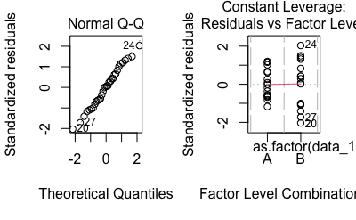

```r
plot(data_1_lm1_factor, which = c(2, 5))
```

> In the first plot (box and whisker plot), Variety B has a larger spread, so we will need to measure whether the apparent differences in mean are significant when compared to the spread of the data.

> In the second plat, residuals of this data matches the line representing the theoretical normal distiribution.

> In the third plot, it looks like the assumptions of normality are met for Variety A, and are plausibly met for Variety B (though there are some gaps). However, as hinted at in the box and whisker plot, Variety B has a larger spread, so we need to take caution with this assumption.

## 1.10 Prepare a table showing the number of replicates required to detect significant differences (alpha = 0.01, power = 0.9) between means that are 1, 2, 4, 8, or 16 cm apart, assuming that the population standard deviation is 4cm. Use the function `power.t.test`. How much easier is it to detect a difference of 16cm than one of 1 cm?

```r
delta = c(1,2,4,8,16)

# Here's a hit at how to calculate the sample size for the first delta

reps[1] <- power.t.test(n = NULL,  # make sure to fill in ALL of the ?
                        delta = delta[1],
                        sd = 4,
                        sig.level = 0.01,
                        power = 0.9,
                        type = 'two.sample',
                        alternative = 'two.sided'
                        )$n
reps[2] <- power.t.test(n = NULL,  # make sure to fill in ALL of the ?
                        delta = delta[2],
                        sd = 4,
                        sig.level = 0.01,
                        power = 0.9,
                        type = 'two.sample',
                        alternative = 'two.sided'
                        )$n
reps[3] <- power.t.test(n = NULL,  # make sure to fill in ALL of the ?
                        delta = delta[3],
                        sd = 4,
                        sig.level = 0.01,
                        power = 0.9,
                        type = 'two.sample',
                        alternative = 'two.sided'
                        )$n
reps[4] <- power.t.test(n = NULL,  # make sure to fill in ALL of the ?
                        delta = delta[4],
                        sd = 4,
                        sig.level = 0.01,
                        power = 0.9,
                        type = 'two.sample',
                        alternative = 'two.sided'
                        )$n
reps[5] <- power.t.test(n = NULL,  # make sure to fill in ALL of the ?
                        delta = delta[5],
                        sd = 4,
                        sig.level = 0.01,
                        power = 0.9,
                        type = 'two.sample',
                        alternative = 'two.sided'
                        )$n


reps[1]
reps[2]
reps[3]
reps[4]
reps[5]
reps = c(reps[1:5])

# Here we make a table of the results.
ans_4.4 <- data.frame(delta,reps)
ans_4.4
```

| mean diff | reps |
| --- | --- |
| 1 | 478 |
| 2 | 121 |
| 4 | 31 |
| 8 | 9 |
| 16 | 4 |

> It is much easier to detect a difference of 16 cm. This is evidenced by the number of reps required to detect a difference of 16 cm 90% of the time.